# Exercise 9 – Random Forests

[Introduction to Machine Learning](https://slds-lmu.github.io/i2ml/)

## Exercise 1: Bagging

**Only for lecture group A**

**Learning goals**

TBD

In this exercise, we briefly revisit why bagging is a useful technique to stabilize predictions.

For a fixed observation $(\mathbf{x}, y)$, show that the expected quadratic loss over individual base learner predictions $b^{[m]}(\mathbf{x})$ is larger than or equal to the expected quadratic loss of the prediction $f^{[M]}(\mathbf{x})$ of a size-$M$ ensemble ($M \in \mathbb{N}$).

You can consider all hyperparameters of the base learners and the ensemble fixed.

**Hint**

**Solution**

Let’s first think about the expectation – what is the stochastic part we integrate over? Since the base learner and ensemble structure is fixed for given data, the only thing random is the bootstrap sample we use as training data for the $m$-th tree, given that the total available training data originate from the data-generating process $\mathbb{P}_{xy}$, so we could write $\mathbb{E}_{\mathcal{D}_{\text{train}}^{[m]} ~|~ \mathcal{D}_{\text{train}}\sim \mathbb{P}_{xy}}$ (for ease of notation, we’ll omit the subscripts of the expectation from now on).

Next, consider the quantity we are supposed to compare to another quantity: $\mathbb{E}\left( \left(y - b^{[m]}(\mathbf{x})\right)^2 \right)$. This looks already a lot like the $\mathbb{E}(Z^2)$ part of the LOTV.

Since the expectation is linear, it is often worthwhile to decompose expressions of expectation and isolate the stochastic parts. Here, the only thing that changes w.r.t. $\mathcal{D}_{\text{train}}^{[m]}$ is the base learner models $b^{[m]}(\mathbf{x})$:

$$\mathbb{E}\left( \left(y - b^{[m]}(\mathbf{x})\right)^2\right)
= \mathbb{E}\left(y^2 - 2y b^{[m]}(\mathbf{x})+ \left(b^{[m]}(\mathbf{x})\right)^2 \right)
= y^2 - 2y \mathbb{E}\left(b^{[m]}(\mathbf{x})\right) + \mathbb{E}\left( \left(
b^{[m]}(\mathbf{x})\right)^2 \right),$$

$$y^2 - 2y \mathbb{E}\left(b^{[m]}(\mathbf{x})\right) + \left( \mathbb{E}
\left(b^{[m]}(\mathbf{x})\right) \right)^2 = \left( y - \mathbb{E}\left(b^{[m]}(\mathbf{x})\right) \right)^2$$

Combine the two parts using the LOTV:

$$\mathbb{E}\left( \left(y - b^{[m]}(\mathbf{x})\right)^2\right) \geq \left( y - \mathbb{E}\left(b^{[m]}(\mathbf{x})\right) \right)^2 .$$

$$\mathbb{E}\left(b^{[m]}(\mathbf{x})\right) = \sum_{m = 1}^M b^{[m]}(\mathbf{x})p \left(\mathcal{D}_{\text{train}}^{[m]} \right)
= \sum_{m = 1}^M b^{[m]}(\mathbf{x})\cdot \frac{1}{M}
= \frac{1}{M} \sum_{m = 1}^M b^{[m]}(\mathbf{x}),$$

which is precisely the ensemble prediction $f^{[M]}(\mathbf{x})$.

Putting everything together, we get

$$\mathbb{E}\left( \left(y - b^{[m]}(\mathbf{x})\right)^2\right) \geq \left( y - \left(f^{[M]}(\mathbf{x})\right) \right)^2,$$

showing that the expected quadratic loss over individual base learner predictions is at least as large as the expected loss of the ensemble prediction.

## Exercise 2: Classifying spam

**Learning goals**

TBD

**Only for lecture group B**

Take a look at the `spam` dataset and shortly describe what kind of classification problem this is.

**Hint**

**R**

Access the corresponding task `?mlr3::mlr_tasks_spam`.

**Python**

Read spam.csv.

**Solution**

The `spam` data is a binary classification task where the aim is to classify an e-mail as spam or non-spam:

**R**

```r
library(mlr3)
tsk("spam")
```

```
<TaskClassif:spam> (4601 x 58): HP Spam Detection
* Target: type
* Properties: twoclass
* Features (57):
  - dbl (57): address, addresses, all, business, capitalAve,
    capitalLong, capitalTotal, charDollar, charExclamation, charHash,
    charRoundbracket, charSemicolon, charSquarebracket, conference,
    credit, cs, data, direct, edu, email, font, free, george, hp, hpl,
    internet, lab, labs, mail, make, meeting, money, num000, num1999,
    num3d, num415, num650, num85, num857, order, original, our, over,
    parts, people, pm, project, re, receive, remove, report, table,
    technology, telnet, will, you, your
```

**Python**

```python
data_spam = pd.read_csv("../data/spam.csv")
data_spam.drop(data_spam.columns[[0]], axis=1, inplace=True)

X_spam = data_spam.copy() # note without copy() X_spam is not a variable but a pointer
y_spam = X_spam.pop("type")

print(y_spam.value_counts())
```

```
type
nonspam    2788
spam       1813
Name: count, dtype: int64
```

```python
print(X_spam.describe().head())
```

```
           address    addresses          all     business   capitalAve  \
count  4601.000000  4601.000000  4601.000000  4601.000000  4601.000000
mean      0.213015     0.049205     0.280656     0.142586     5.191515
std       1.290575     0.258843     0.504143     0.444055    31.729449
min       0.000000     0.000000     0.000000     0.000000     1.000000
25%       0.000000     0.000000     0.000000     0.000000     1.588000

       capitalLong  capitalTotal   charDollar  charExclamation     charHash  \
count  4601.000000   4601.000000  4601.000000      4601.000000  4601.000000
mean     52.172789    283.289285     0.075811         0.269071     0.044238
std     194.891310    606.347851     0.245882         0.815672     0.429342
min       1.000000      1.000000     0.000000         0.000000     0.000000
25%       6.000000     35.000000     0.000000         0.000000     0.000000

       ...           re      receive       remove       report        table  \
count  ...  4601.000000  4601.000000  4601.000000  4601.000000  4601.000000
mean   ...     0.301224     0.059824     0.114208     0.058626     0.005444
std    ...     1.011687     0.201545     0.391441     0.335184     0.076274
min    ...     0.000000     0.000000     0.000000     0.000000     0.000000
25%    ...     0.000000     0.000000     0.000000     0.000000     0.000000

        technology       telnet         will          you         your
count  4601.000000  4601.000000  4601.000000  4601.000000  4601.000000
mean      0.097477     0.064753     0.541702     1.662100     0.809761
std       0.402623     0.403393     0.861698     1.775481     1.200810
min       0.000000     0.000000     0.000000     0.000000     0.000000
25%       0.000000     0.000000     0.000000     0.000000     0.000000

[5 rows x 57 columns]
```

**Only for lecture group B**

Use a decision tree to predict `spam`. Re-fit the tree using two random subsets of the data (each comprising 60% of observations). How stable are the trees?

**Hint**

**R**

Use `rpart.plot()` from the package `rpart.plot` to visualize the trees.

**Python**

Use `from sklearn.tree import plot_tree` to visualize the trees.

**Solution**

**R**

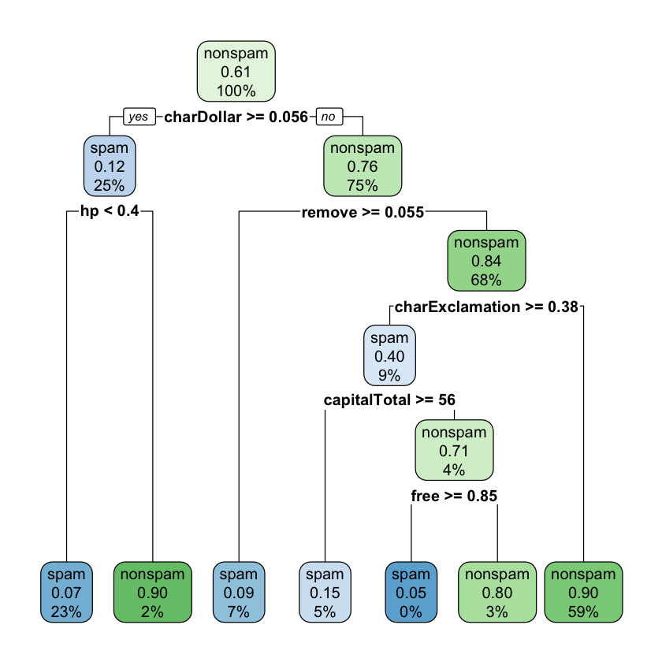

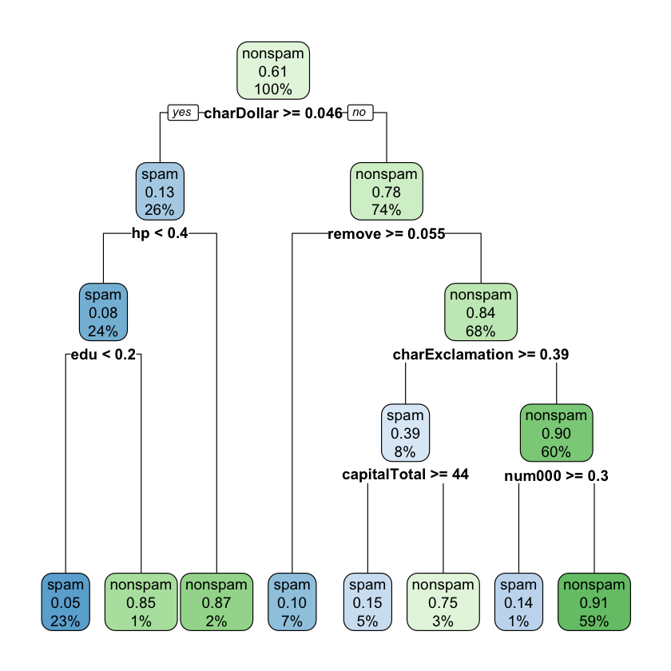

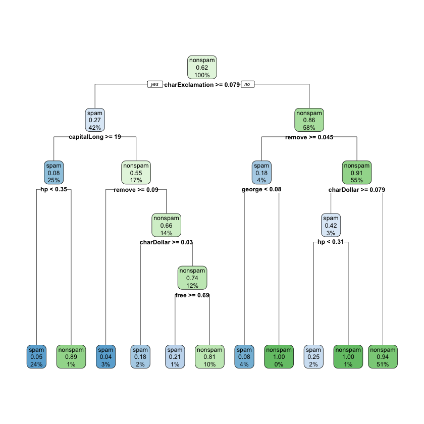

```r
library(rpart.plot)
task_spam <- tsk("spam")

learner <- lrn("classif.rpart")
learner$train(task_spam)

set.seed(123)
rpart.plot(learner$model, roundint = FALSE)

set.seed(456)
subset_1 <- sample.int(task_spam$nrow, size = 0.6 * task_spam$nrow)
set.seed(789)
subset_2 <- sample.int(task_spam$nrow, size = 0.6 * task_spam$nrow)

for (i in list(subset_1, subset_2)) {
  learner$train(task_spam, row_ids = i)
  rpart.plot(learner$model, roundint = FALSE)
}
```

**Python**

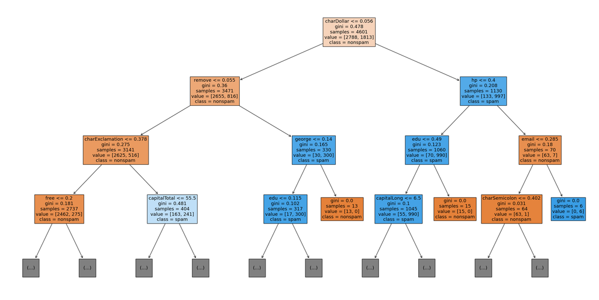

```python
# train on full data set
random_state = 43
tree_class_full = DecisionTreeClassifier()
tree_class_full.fit(X_spam, y_spam)
class_names=data_spam.type.unique().tolist()
class_names.sort()
# use plot_tree to visualize the decision tree
plt.figure(figsize=(30,15))
plot_tree(tree_class_full, max_depth=3, feature_names=X_spam.columns, class_names = class_names, filled=True, fontsize=13)
plt.show()
```

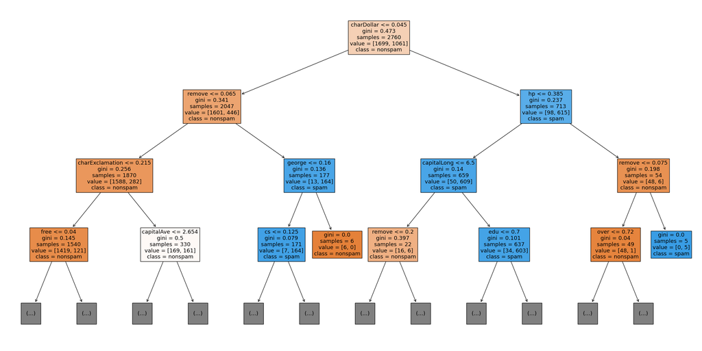

```python
# train on first random 60% split
random_state = 42
X_train, X_test, y_train, y_test = train_test_split(X_spam, y_spam, train_size = 0.6, random_state=random_state)

tree_class_sub1 = DecisionTreeClassifier()
tree_class_sub1.fit(X_train, y_train)
# use plot_tree to visualize the decision tree
plt.figure(figsize=(30,15))
plot_tree(tree_class_sub1, max_depth=3, feature_names=X_train.columns, class_names = class_names, filled=True, fontsize=13)
plt.show()
```

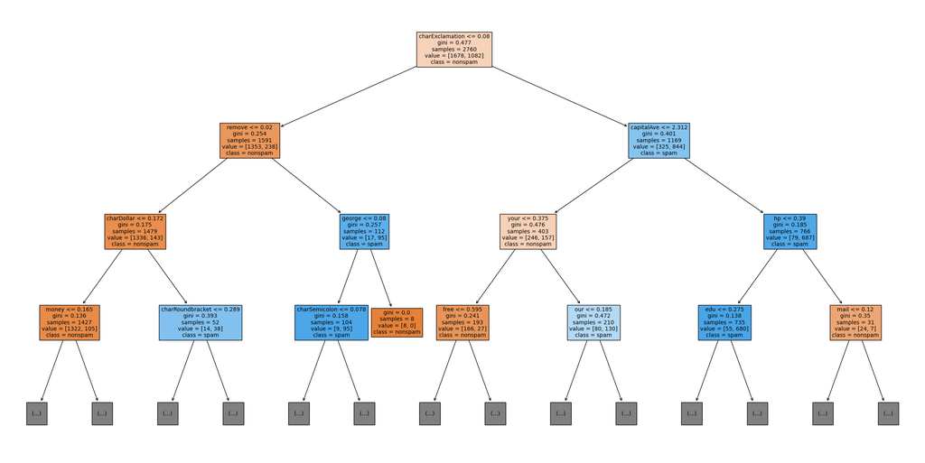

```python
# train on second random 60% split
random_state = 321
X_train, X_test, y_train, y_test = train_test_split(X_spam, y_spam, train_size = 0.6, random_state=random_state)

tree_class_sub2 = DecisionTreeClassifier()
tree_class_sub2.fit(X_train, y_train)
# use plot_tree to visualize the decision tree
plt.figure(figsize=(30,15))
plot_tree(tree_class_sub2, max_depth=3, feature_names=X_train.columns, class_names = class_names, filled=True, fontsize=10)
plt.show()
```

Observation: trees trained on different samples differ considerably in their structure, regarding split variables as well as thresholds (recall, though, that the split candidates are a further source of randomness).

Forests come with a built-in estimate of their generalization ability via the out-of-bag (OOB) error.

> 1. Show that the probability for an observation to be OOB in an arbitrary bootstrap sample converges to $\tfrac{1}{e}$.
> 2. Use the random forest learner (R: `classif.ranger`, Python: `RandomForestClassifier()` to fit the model and state the out-of-bag (OOB) error.

**Solution**

1. This is actually quite easy when we recall that the exponential function at an arbitrary input $x$ can be characterized via $e^x = \lim_{n \to \infty} \left( 1 + \tfrac{x}{n} \right)^n$, which already resembles the limit expression we are looking for. Setting $x$ to -1 yields:

$$\lim_{n \to \infty} \left( 1 - \tfrac{1}{n} \right)^n = e^{-1} =
\tfrac{1}{e}.$$

2. OOB-error can be computed by:

**R**

```r
library(mlr3learners)

learner <- lrn("classif.ranger", "oob.error" = TRUE)
learner$train(tsk("spam"))
learner$model$prediction.error
```

0.0469463160182569

**Python**

```python
crf_full = RandomForestClassifier(random_state=43, oob_score = True)
crf_full.fit(X_spam, y_spam)

print("OOB-error: ", 1 - crf_full.oob_score_)
```

```
OOB-error:  0.04564225168441638
```

You are interested in which variables have the greatest influence on the prediction quality. Explain how to determine this in a permutation-based approach and compute the importance scorses for the data.

**Hint**

**R**

Use an adequate variable importance filter as described [here](https://mlr3filters.mlr-org.com/#variable-importance-filters).

**Python**

Choose an adequate importance measure as described [here](https://scikit-learn.org/stable/auto_examples/ensemble/plot_forest_importances.html).

**Solution**

Variable importance in general measures the contributions of features to a model. One way of computing the variable importance of the $j$-th variable is based on permuting it for the OOB observations and calculating the mean increase in OOB error this permutation entails.

In order to determine the with the biggest influence on prediction quality, we can choose the $k$ variables with the highest importance score, e.g., for $k = 5$:

**R**

```r
library(mlr3filters)

learner <- lrn("classif.ranger", importance = "permutation", "oob.error" = TRUE)
filter <- flt("importance", learner = learner)
filter$calculate(tsk("spam"))
head(as.data.table(filter), 5)
```

A data.table: 5 x 2

| feature <chr> | score <dbl> |
| --- | --- |
| capitalLong | 0.04533696 |
| hp | 0.04197165 |
| charExclamation | 0.03969858 |
| remove | 0.03817609 |
| capitalAve | 0.03455630 |

**Python**

```python
random_state = 321
k = 5
# create a hold-out set and fit another Random Forest Classifier
X_train, X_test, y_train, y_test = train_test_split(X_spam, y_spam, test_size = 0.25, random_state=random_state)
crf_perm = RandomForestClassifier(random_state=random_state)
crf_perm.fit(X_train, y_train)

result = permutation_importance(crf_perm, X_test, y_test, random_state=random_state)
forest_importances = pd.Series(result.importances_mean, index=X_test.columns)
sorted_idx = forest_importances.argsort()
sorted_idx = sorted_idx[::-1] #reverse order
sorted_idx_selected = sorted_idx[:k]

print(forest_importances[sorted_idx_selected])
```

```
remove             0.021025
hp                 0.017376
charExclamation    0.016334
george             0.009731
capitalLong        0.009209
dtype: float64
```

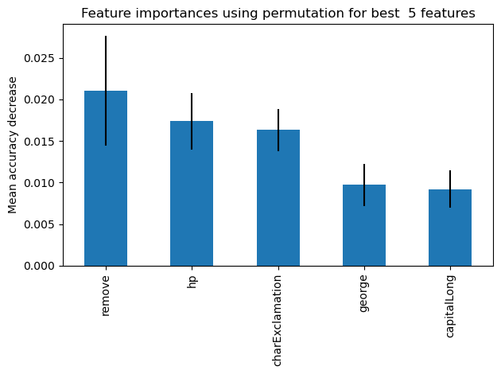

```python
fig, ax = plt.subplots()
forest_importances[sorted_idx_selected].plot.bar(yerr=result.importances_std[sorted_idx_selected], ax=ax)
ax.set_title("Feature importances using permutation for best %2d features" % k)
ax.set_ylabel("Mean accuracy decrease")
fig.tight_layout()
plt.show()
```

## Exercise 3: Proximities

**Learning goals**

TBD

| observation | alcalinity | alcohol | flavanoids | hue | malic | phenols |
| --- | --- | --- | --- | --- | --- | --- |
| 1 | 11.4 | 14.75 | 3.69 | 1.25 | 1.73 | 3.10 |
| 2 | 25.0 | 13.40 | 0.96 | 0.67 | 4.60 | 1.98 |
| 3 | 17.4 | 13.94 | 3.54 | 1.12 | 1.73 | 2.88 |

Tree 1:

| nodeID | leftChild | rightChild | splitvarID | splitvarName | splitval | terminal | prediction |
| --- | --- | --- | --- | --- | --- | --- | --- |
| 0 | 1 | 2 | 5 | phenols | 1.97 | FALSE | NA |
| 1 | 3 | 4 | 1 | alcohol | 12.43 | FALSE | NA |
| 2 | 5 | 6 | 1 | alcohol | 13.03 | FALSE | NA |
| 3 | NA | NA | NA | NA | NA | TRUE | 2 |
| 4 | NA | NA | NA | NA | NA | TRUE | 3 |
| 5 | NA | NA | NA | NA | NA | TRUE | 2 |
| 6 | NA | NA | NA | NA | NA | TRUE | 1 |

Tree 2:

| nodeID | leftChild | rightChild | splitvarID | splitvarName | splitval | terminal | prediction |
| --- | --- | --- | --- | --- | --- | --- | --- |
| 0 | 1 | 2 | 1 | alcohol | 12.78 | FALSE | NA |
| 1 | 3 | 4 | 3 | hue | 0.68 | FALSE | NA |
| 2 | 5 | 6 | 2 | flavanoids | 2.18 | FALSE | NA |
| 3 | NA | NA | NA | NA | NA | TRUE | 3 |
| 4 | NA | NA | NA | NA | NA | TRUE | 2 |
| 5 | NA | NA | NA | NA | NA | TRUE | 3 |
| 6 | NA | NA | NA | NA | NA | TRUE | 1 |

Tree 3:

| nodeID | leftChild | rightChild | splitvarID | splitvarName | splitval | terminal | prediction |
| --- | --- | --- | --- | --- | --- | --- | --- |
| 0 | 1 | 2 | 1 | alcohol | 12.79 | FALSE | NA |
| 1 | 3 | 4 | 5 | phenols | 2.01 | FALSE | NA |
| 2 | 5 | 6 | 5 | phenols | 2.28 | FALSE | NA |
| 3 | NA | NA | NA | NA | NA | TRUE | 2 |
| 4 | NA | NA | NA | NA | NA | TRUE | 2 |
| 5 | NA | NA | NA | NA | NA | TRUE | 3 |
| 6 | NA | NA | NA | NA | NA | TRUE | 1 |

For the following subset of the training data and the random forest model given above,

find the terminal node of each tree the observations are placed in,

**Solution**

```
   tree_1  tree_2  tree_3
0       6       6       6
1       6       5       5
2       6       6       6
```

compute the observations’ pairwise proximities, and

**Solution**

For the proximities, we consider each pair of observations and compute the relative frequency of trees assigning them to the same terminal node.

- Observations 1 and 2: only tree 1 assigns them to the same node, so the proximity is $\tfrac{1}{3}$.
- Observations 1 and 3: all trees assign them to the same node, so the proximity is 1.
- Observations 2 and 3: only tree 1 assigns them to the same node, so the proximity is $\tfrac{1}{3}$.

construct a similarity matrix from these proximities in `R` resp. `Python`.

**Solution**

We can put this information into a similarity matrix (as such matrices become large quite quickly for more data, it is common to store only the lower diagonal – the rest is non-informative/redundant):

**R**

```r
compute_prox <- function(i, j) sum(i == j) / length(i)
round(proxy::dist(end_nodes, method = compute_prox), 2L)
```

[output not shown]

**Python**

```python
# Compute the pairwise distances between the rows of X
distances = 1 - pdist(end_nodes, metric='hamming')
# Compute the size of the matrix
n = end_nodes.shape[0]
size = (n * (n - 1)) // 2
# Create a sparse matrix to store the pairwise distances. Sparse matrices only need memory space for values unequal to zero.
distance_matrix = dok_matrix((n, n), dtype=np.float32)
# Populate the lower triangle of the matrix with the distances
i, j = np.tril_indices(n, k=-1)
distance_matrix[i, j] = distances[:size]
# Print the matrix
print(distance_matrix.toarray())
```

```
[[0.         0.         0.        ]
 [0.33333334 0.         0.        ]
 [1.         0.33333334 0.        ]]
```